# Part I - Prosper Loan Data Exploration

## by Elliot Manuel Sithole

29-09-2022

## Introduction

Prosper Marketplace, Inc. is a San Francisco, California-based company involved in the peer-to-peer lending industry. Prosper Funding LLC, one of its subsidiaries, operates Prosper.com, a website where individuals can either invest in personal loans or request to borrow money.The Propser loan [data set](https://www.google.com/url?q=https://s3.amazonaws.com/udacity-hosted-downloads/ud651/prosperLoanData.csv&sa=D&ust=1581581520570000) contains 113,937 loan entries with 81 variables on each loan, including loan amount, borrower rate, current loan status, borrower income, and many others. This [data dictionary](https://www.google.com/url?q=https://docs.google.com/spreadsheet/ccc?key%3D0AllIqIyvWZdadDd5NTlqZ1pBMHlsUjdrOTZHaVBuSlE%26usp%3Dsharing&sa=D&ust=1554486256024000) elaborates on the features contained in the data set.

## Preliminary Wrangling

```python
# import all packages and set plots to be embedded inline
import numpy as np
import pandas as pd
import matplotlib.pyplot as plt
import seaborn as sb

%matplotlib inline
import warnings
warnings.filterwarnings("ignore")
```

> This section of the report, will load in the data, describe and check for cleanliness, and if any need trim and clean the dataset for exploratory analysis.

```python
# load data and inspect
df_loan= pd.read_csv('prosperLoanData.csv')
df_loan.head()
```

|  | ListingKey | ListingNumber | ListingCreationDate | CreditGrade | Term | LoanStatus | ClosedDate | BorrowerAPR | BorrowerRate | LenderYield | ... | LP_ServiceFees | LP_CollectionFees | LP_GrossPrincipalLoss | LP_NetPrincipalLoss | LP_NonPrincipalRecoverypayments | PercentFunded | Recommendations | InvestmentFromFriendsCount | InvestmentFromFriendsAmount | Investors |
| --- | --- | --- | --- | --- | --- | --- | --- | --- | --- | --- | --- | --- | --- | --- | --- | --- | --- | --- | --- | --- | --- |
| 0 | 1021339766868145413AB3B | 193129 | 2007-08-26 19:09:29.263000000 | C | 36 | Completed | 2009-08-14 00:00:00 | 0.16516 | 0.1580 | 0.1380 | ... | -133.18 | 0.0 | 0.0 | 0.0 | 0.0 | 1.0 | 0 | 0 | 0.0 | 258 |
| 1 | 10273602499503308B223C1 | 1209647 | 2014-02-27 08:28:07.900000000 | NaN | 36 | Current | NaN | 0.12016 | 0.0920 | 0.0820 | ... | 0.00 | 0.0 | 0.0 | 0.0 | 0.0 | 1.0 | 0 | 0 | 0.0 | 1 |
| 2 | 0EE9337825851032864889A | 81716 | 2007-01-05 15:00:47.090000000 | HR | 36 | Completed | 2009-12-17 00:00:00 | 0.28269 | 0.2750 | 0.2400 | ... | -24.20 | 0.0 | 0.0 | 0.0 | 0.0 | 1.0 | 0 | 0 | 0.0 | 41 |
| 3 | 0EF5356002482715299901A | 658116 | 2012-10-22 11:02:35.010000000 | NaN | 36 | Current | NaN | 0.12528 | 0.0974 | 0.0874 | ... | -108.01 | 0.0 | 0.0 | 0.0 | 0.0 | 1.0 | 0 | 0 | 0.0 | 158 |
| 4 | 0F023589499656230C5E3E2 | 909464 | 2013-09-14 18:38:39.097000000 | NaN | 36 | Current | NaN | 0.24614 | 0.2085 | 0.1985 | ... | -60.27 | 0.0 | 0.0 | 0.0 | 0.0 | 1.0 | 0 | 0 | 0.0 | 20 |

5 rows × 81 columns

```python
df_loan.info()
```

```
<class 'pandas.core.frame.DataFrame'>
RangeIndex: 113937 entries, 0 to 113936
Data columns (total 81 columns):
 #   Column                               Non-Null Count   Dtype
---  ------                               --------------   -----
 0   ListingKey                           113937 non-null  object
 1   ListingNumber                        113937 non-null  int64
 2   ListingCreationDate                  113937 non-null  object
 3   CreditGrade                          28953 non-null   object
 4   Term                                 113937 non-null  int64
 5   LoanStatus                           113937 non-null  object
 6   ClosedDate                           55089 non-null   object
 7   BorrowerAPR                          113912 non-null  float64
 8   BorrowerRate                         113937 non-null  float64
 9   LenderYield                          113937 non-null  float64
```

[output cut: 73 more lines]

```python
df_loan.describe()
```

|  | ListingNumber | Term | BorrowerAPR | BorrowerRate | LenderYield | EstimatedEffectiveYield | EstimatedLoss | EstimatedReturn | ProsperRating (numeric) | ProsperScore | ... | LP_ServiceFees | LP_CollectionFees | LP_GrossPrincipalLoss | LP_NetPrincipalLoss | LP_NonPrincipalRecoverypayments | PercentFunded | Recommendations | InvestmentFromFriendsCount | InvestmentFromFriendsAmount | Investors |
| --- | --- | --- | --- | --- | --- | --- | --- | --- | --- | --- | --- | --- | --- | --- | --- | --- | --- | --- | --- | --- | --- |
| count | 1.139370e+05 | 113937.000000 | 113912.000000 | 113937.000000 | 113937.000000 | 84853.000000 | 84853.000000 | 84853.000000 | 84853.000000 | 84853.000000 | ... | 113937.000000 | 113937.000000 | 113937.000000 | 113937.000000 | 113937.000000 | 113937.000000 | 113937.000000 | 113937.000000 | 113937.000000 | 113937.000000 |
| mean | 6.278857e+05 | 40.830248 | 0.218828 | 0.192764 | 0.182701 | 0.168661 | 0.080306 | 0.096068 | 4.072243 | 5.950067 | ... | -54.725641 | -14.242698 | 700.446342 | 681.420499 | 25.142686 | 0.998584 | 0.048027 | 0.023460 | 16.550751 | 80.475228 |
| std | 3.280762e+05 | 10.436212 | 0.080364 | 0.074818 | 0.074516 | 0.068467 | 0.046764 | 0.030403 | 1.673227 | 2.376501 | ... | 60.675425 | 109.232758 | 2388.513831 | 2357.167068 | 275.657937 | 0.017919 | 0.332353 | 0.232412 | 294.545422 | 103.239020 |
| min | 4.000000e+00 | 12.000000 | 0.006530 | 0.000000 | -0.010000 | -0.182700 | 0.004900 | -0.182700 | 1.000000 | 1.000000 | ... | -664.870000 | -9274.750000 | -94.200000 | -954.550000 | 0.000000 | 0.700000 | 0.000000 | 0.000000 | 0.000000 | 1.000000 |
| 25% | 4.009190e+05 | 36.000000 | 0.156290 | 0.134000 | 0.124200 | 0.115670 | 0.042400 | 0.074080 | 3.000000 | 4.000000 | ... | -73.180000 | 0.000000 | 0.000000 | 0.000000 | 0.000000 | 1.000000 | 0.000000 | 0.000000 | 0.000000 | 2.000000 |
| 50% | 6.005540e+05 | 36.000000 | 0.209760 | 0.184000 | 0.173000 | 0.161500 | 0.072400 | 0.091700 | 4.000000 | 6.000000 | ... | -34.440000 | 0.000000 | 0.000000 | 0.000000 | 0.000000 | 1.000000 | 0.000000 | 0.000000 | 0.000000 | 44.000000 |
| 75% | 8.926340e+05 | 36.000000 | 0.283810 | 0.250000 | 0.240000 | 0.224300 | 0.112000 | 0.116600 | 5.000000 | 8.000000 | ... | -13.920000 | 0.000000 | 0.000000 | 0.000000 | 0.000000 | 1.000000 | 0.000000 | 0.000000 | 0.000000 | 115.000000 |
| max | 1.255725e+06 | 60.000000 | 0.512290 | 0.497500 | 0.492500 | 0.319900 | 0.366000 | 0.283700 | 7.000000 | 11.000000 | ... | 32.060000 | 0.000000 | 25000.000000 | 25000.000000 | 21117.900000 | 1.012500 | 39.000000 | 33.000000 | 25000.000000 | 1189.000000 |

8 rows × 61 columns

```python
df_loan.shape
```

```
(113937, 81)
```

```python
# Make copies of original pieces of data
df_og= df_loan.copy()
```

```python
# trim and select these features for further analysis
df = df_og[['LoanKey','Term','LoanStatus','BorrowerAPR','BorrowerRate','ListingCategory (numeric)','BorrowerState','Occupation','EmploymentStatus','LoanOriginalAmount','CreditScoreRangeLower','CreditScoreRangeUpper','DebtToIncomeRatio','Investors','StatedMonthlyIncome','MonthlyLoanPayment',
       'IncomeVerifiable','IsBorrowerHomeowner']]
df.head()
```

|  | LoanKey | Term | LoanStatus | BorrowerAPR | BorrowerRate | ListingCategory (numeric) | BorrowerState | Occupation | EmploymentStatus | LoanOriginalAmount | CreditScoreRangeLower | CreditScoreRangeUpper | DebtToIncomeRatio | Investors | StatedMonthlyIncome | MonthlyLoanPayment | IncomeVerifiable | IsBorrowerHomeowner |
| --- | --- | --- | --- | --- | --- | --- | --- | --- | --- | --- | --- | --- | --- | --- | --- | --- | --- | --- |
| 0 | E33A3400205839220442E84 | 36 | Completed | 0.16516 | 0.1580 | 0 | CO | Other | Self-employed | 9425 | 640.0 | 659.0 | 0.17 | 258 | 3083.333333 | 330.43 | True | True |
| 1 | 9E3B37071505919926B1D82 | 36 | Current | 0.12016 | 0.0920 | 2 | CO | Professional | Employed | 10000 | 680.0 | 699.0 | 0.18 | 1 | 6125.000000 | 318.93 | True | False |
| 2 | 6954337960046817851BCB2 | 36 | Completed | 0.28269 | 0.2750 | 0 | GA | Other | Not available | 3001 | 480.0 | 499.0 | 0.06 | 41 | 2083.333333 | 123.32 | True | False |
| 3 | A0393664465886295619C51 | 36 | Current | 0.12528 | 0.0974 | 16 | GA | Skilled Labor | Employed | 10000 | 800.0 | 819.0 | 0.15 | 158 | 2875.000000 | 321.45 | True | True |
| 4 | A180369302188889200689E | 36 | Current | 0.24614 | 0.2085 | 2 | MN | Executive | Employed | 15000 | 680.0 | 699.0 | 0.26 | 20 | 9583.333333 | 563.97 | True | True |

```python
#clean column names
# first-pip install skimpy
from skimpy import clean_columns
df1 = clean_columns(df)
df1.columns.tolist()
```

```
['loan_key',
 'term',
 'loan_status',
 'borrower_apr',
 'borrower_rate',
 'listing_category_numeric',
 'borrower_state',
 'occupation',
 'employment_status',
 'loan_original_amount',
 'credit_score_range_lower',
 'credit_score_range_upper',
 'debt_to_income_ratio',
 'investors',
 'stated_monthly_income',
 'monthly_loan_payment',
 'income_verifiable',
 'is_borrower_homeowner']
```

```python
# check the df shape
df1.shape
```

```
(113937, 18)
```

```python
#check selected features charactoristics
df1.info()
```

```
<class 'pandas.core.frame.DataFrame'>
RangeIndex: 113937 entries, 0 to 113936
Data columns (total 18 columns):
 #   Column                    Non-Null Count   Dtype
---  ------                    --------------   -----
 0   loan_key                  113937 non-null  object
 1   term                      113937 non-null  int64
 2   loan_status               113937 non-null  object
 3   borrower_apr              113912 non-null  float64
 4   borrower_rate             113937 non-null  float64
 5   listing_category_numeric  113937 non-null  int64
 6   borrower_state            108422 non-null  object
 7   occupation                110349 non-null  object
 8   employment_status         111682 non-null  object
 9   loan_original_amount      113937 non-null  int64
 10  credit_score_range_lower  113346 non-null  float64
 11  credit_score_range_upper  113346 non-null  float64
 12  debt_to_income_ratio      105383 non-null  float64
 13  investors                 113937 non-null  int64
 14  stated_monthly_income     113937 non-null  float64
 15  monthly_loan_payment      113937 non-null  float64
 16  income_verifiable         113937 non-null  bool
 17  is_borrower_homeowner     113937 non-null  bool
dtypes: bool(2), float64(7), int64(4), object(5)
memory usage: 14.1+ MB
```

```python
# inspect and clean for duplicates
df1.duplicated().value_counts()
```

```
False    113066
True        871
dtype: int64
```

```python
# remove duplicates and confirm removal.
df_new= df1.drop_duplicates()
df_new.duplicated().value_counts()
```

```
False    113066
dtype: int64
```

```python
#check for null values
df_new.isnull().sum()
```

```
loan_key                       0
term                           0
loan_status                    0
borrower_apr                  25
borrower_rate                  0
listing_category_numeric       0
borrower_state              5515
occupation                  3529
employment_status           2255
loan_original_amount           0
credit_score_range_lower     591
credit_score_range_upper     591
debt_to_income_ratio        8472
investors                      0
stated_monthly_income          0
monthly_loan_payment           0
income_verifiable              0
is_borrower_homeowner          0
dtype: int64
```

```python
# replace null values in employment status column with Not Available
# replace null values in occupation column with Not Provided
df_new['employment_status'].fillna("Not available",inplace=True)
df_new['occupation'].fillna("Not_provided",inplace=True)
```

```python
# confirm changes- employment status
df_new['employment_status'].isnull().sum()
```

```
0
```

```python
# confirm changes- occupation
df_new['occupation'].isnull().sum()
```

```
0
```

```python
# drop null values in all other columns and confirm removal
df_clean=df_new.dropna()
df_clean.isnull().sum()
```

```
loan_key                    0
term                        0
loan_status                 0
borrower_apr                0
borrower_rate               0
listing_category_numeric    0
borrower_state              0
occupation                  0
employment_status           0
loan_original_amount        0
credit_score_range_lower    0
credit_score_range_upper    0
debt_to_income_ratio        0
investors                   0
stated_monthly_income       0
monthly_loan_payment        0
income_verifiable           0
is_borrower_homeowner       0
dtype: int64
```

```python
df_clean.head()
```

|  | loan_key | term | loan_status | borrower_apr | borrower_rate | listing_category_numeric | borrower_state | occupation | employment_status | loan_original_amount | credit_score_range_lower | credit_score_range_upper | debt_to_income_ratio | investors | stated_monthly_income | monthly_loan_payment | income_verifiable | is_borrower_homeowner |
| --- | --- | --- | --- | --- | --- | --- | --- | --- | --- | --- | --- | --- | --- | --- | --- | --- | --- | --- |
| 0 | E33A3400205839220442E84 | 36 | Completed | 0.16516 | 0.1580 | 0 | CO | Other | Self-employed | 9425 | 640.0 | 659.0 | 0.17 | 258 | 3083.333333 | 330.43 | True | True |
| 1 | 9E3B37071505919926B1D82 | 36 | Current | 0.12016 | 0.0920 | 2 | CO | Professional | Employed | 10000 | 680.0 | 699.0 | 0.18 | 1 | 6125.000000 | 318.93 | True | False |
| 2 | 6954337960046817851BCB2 | 36 | Completed | 0.28269 | 0.2750 | 0 | GA | Other | Not available | 3001 | 480.0 | 499.0 | 0.06 | 41 | 2083.333333 | 123.32 | True | False |
| 3 | A0393664465886295619C51 | 36 | Current | 0.12528 | 0.0974 | 16 | GA | Skilled Labor | Employed | 10000 | 800.0 | 819.0 | 0.15 | 158 | 2875.000000 | 321.45 | True | True |
| 4 | A180369302188889200689E | 36 | Current | 0.24614 | 0.2085 | 2 | MN | Executive | Employed | 15000 | 680.0 | 699.0 | 0.26 | 20 | 9583.333333 | 563.97 | True | True |

```python
df_clean.shape
```

```
(99151, 18)
```

### What is the structure of your dataset?

> The clean dataset to work on contains 99151 rows and 18 columns.

### What is/are the main feature(s) of interest in your dataset?

> loan_key  
> term  
> loan_status  
> borrower_apr  
> borrower_rate  
> listing_category_numeric  
> borrower_state  
> occupation  
> employment_status  
> loan_original_amount  
> credit_score_range_lower  
> credit_score_range_upper  
> debt_to_income_ratio  
> investors  
> stated_monthly_income  
> monthly_loan_payment  
> income_verifiable  
> is_borrower_homeowner

### What features in the dataset do you think will help support your investigation into your feature(s) of interest?

> The main focus will be on loan status and borrower-APR, loooking at relationships and trends of these and other categorical and numerical variables in the data set.

## Univariate Exploration

> Thi section, will investigate distributions of individual variables. For unusual points or outliers, and take a deeper look to clean things up and prepare to look for relationships between variables.

**What was the most frequent length of the loan term as expressed in months?**

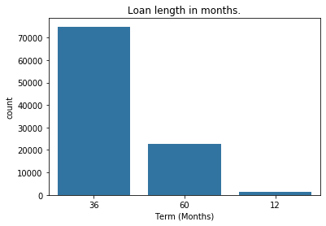

```python
# get count of loans and distibution across months
base_color = sb.color_palette()[0]
sb.countplot(data=df_clean, x= 'term', color=base_color, order= df_clean['term'].value_counts().index)
plt.xlabel('Term (Months)')
plt.title('Loan length in months.');
```

> **The most frequent loan term was for 3 years(36 months), and followed by a 5 year term**

> **How is the distribution of the loan status by frequency?**

```python
#get distribution of loan status by counts
df_clean.loan_status.value_counts()
```

```
Current                   51712
Completed                 31490
Chargedoff                 9732
Defaulted                  4180
Past Due (1-15 days)        716
Past Due (31-60 days)       325
Past Due (91-120 days)      277
Past Due (61-90 days)       274
Past Due (16-30 days)       242
FinalPaymentInProgress      187
Past Due (>120 days)         14
Cancelled                     2
Name: loan_status, dtype: int64
```

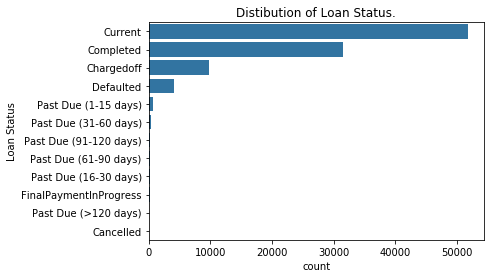

```python
# visualise the loan status distribution
base_color = sb.color_palette()[0]
sb.countplot(data=df_clean, y= 'loan_status', color=base_color, order= df_clean['loan_status'].value_counts().index)
plt.ylabel('Loan Status')
plt.title('Distibution of Loan Status.');
```

> **Most loan status were *current* and followed by the *completed* ones.**

```python
df_clean.describe()
```

|  | term | borrower_apr | borrower_rate | listing_category_numeric | loan_original_amount | credit_score_range_lower | credit_score_range_upper | debt_to_income_ratio | investors | stated_monthly_income | monthly_loan_payment |
| --- | --- | --- | --- | --- | --- | --- | --- | --- | --- | --- | --- |
| count | 99151.000000 | 99151.000000 | 99151.000000 | 99151.000000 | 99151.000000 | 99151.000000 | 99151.000000 | 99151.000000 | 99151.000000 | 99151.000000 | 99151.000000 |
| mean | 41.188208 | 0.217751 | 0.191271 | 2.869875 | 8587.378846 | 687.856300 | 706.856300 | 0.273312 | 82.081522 | 5694.758923 | 278.491379 |
| std | 10.678999 | 0.080025 | 0.074560 | 4.055171 | 6352.556218 | 62.062277 | 62.062277 | 0.510596 | 106.042350 | 4960.961407 | 194.296414 |
| min | 12.000000 | 0.006530 | 0.000000 | 0.000000 | 1000.000000 | 0.000000 | 19.000000 | 0.000000 | 1.000000 | 0.000000 | 0.000000 |
| 25% | 36.000000 | 0.155385 | 0.131400 | 1.000000 | 4000.000000 | 660.000000 | 679.000000 | 0.150000 | 1.000000 | 3333.333333 | 135.820000 |
| 50% | 36.000000 | 0.208080 | 0.181900 | 1.000000 | 7000.000000 | 680.000000 | 699.000000 | 0.220000 | 44.000000 | 4833.333333 | 226.820000 |
| 75% | 36.000000 | 0.280780 | 0.249900 | 3.000000 | 12000.000000 | 720.000000 | 739.000000 | 0.320000 | 118.000000 | 6916.666667 | 377.655000 |
| max | 60.000000 | 0.423950 | 0.360000 | 20.000000 | 35000.000000 | 880.000000 | 899.000000 | 10.010000 | 1189.000000 | 483333.333333 | 2251.510000 |

> **How is the distribution of borrower's APR?**

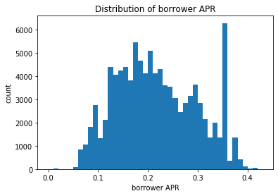

```python
# Plotting histogram.
bins = np.arange(0,df_clean['borrower_apr'].max()+0.01, 0.01)
plt.hist(x='borrower_apr', data= df_clean,bins=bins)
plt.title('Distribution of borrower APR')
plt.xlabel('borrower APR')
plt.ylabel('count');
```

> **Approximately, 0.2 is the average borower's annual percentage rate but however, the distribution is bimodal with peak counts way higher than the average between 0.28 and 0.38. This is more evident on decreasing the bin size to 0.001.**

> **How is the distribution of borrower's rate?**

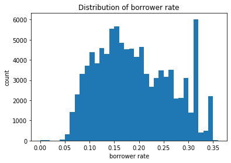

```python
# Plotting histogram.
bins = np.arange(0,df_clean['borrower_rate'].max()+0.01, 0.01)
plt.hist(x='borrower_rate', data= df_clean,bins=bins)
plt.title('Distribution of borrower rate')
plt.xlabel('borrower rate')
plt.ylabel('count');
```

> **The borrower's rate follows a similar distribution pattern to the APR, however, the rate has a significantly higher peak count (0.30 to 035) compared to the average, more apparent when the bin size is reduced to 0.001.**

> **What is the distribution of the credit score?**

> First create a new column from credit score range upper and lower to categorized credit score from poor, fair, good and excellent.

> utilise the *describe()* output for cut-of values

```python
# determine the credit score avarage from lower and upper scores.
df_clean['credit_score_avg'] = df_clean[['credit_score_range_lower','credit_score_range_upper']
                                       ].mean(axis=1)
```

```python
#confirm changes
df_clean.sample(1)
```

|  | loan_key | term | loan_status | borrower_apr | borrower_rate | listing_category_numeric | borrower_state | occupation | employment_status | loan_original_amount | credit_score_range_lower | credit_score_range_upper | debt_to_income_ratio | investors | stated_monthly_income | monthly_loan_payment | income_verifiable | is_borrower_homeowner | credit_score_avg |
| --- | --- | --- | --- | --- | --- | --- | --- | --- | --- | --- | --- | --- | --- | --- | --- | --- | --- | --- | --- |
| 89564 | 4A2D3683410229116F8B94C | 60 | Current | 0.21566 | 0.1914 | 1 | ID | Clerical | Employed | 10000 | 720.0 | 739.0 | 0.31 | 1 | 3750.0 | 260.18 | True | False | 729.5 |

```python
#group using credit lower score cut-offs
def credit_score(c):
    outcome=""
    if c <= 660 :
        outcome = "Poor"
    if c>=660:
        outcome = "Fair"
    if c>=680:
        outcome = "Good"
    if c>=720:
        outcome = "Excellent"
    return outcome
df_clean['credit_score'] = df_clean['credit_score_avg'].apply(credit_score)
```

```python
#confirm changes
df_clean.sample(1)
```

|  | loan_key | term | loan_status | borrower_apr | borrower_rate | listing_category_numeric | borrower_state | occupation | employment_status | loan_original_amount | credit_score_range_lower | credit_score_range_upper | debt_to_income_ratio | investors | stated_monthly_income | monthly_loan_payment | income_verifiable | is_borrower_homeowner | credit_score_avg | credit_score |
| --- | --- | --- | --- | --- | --- | --- | --- | --- | --- | --- | --- | --- | --- | --- | --- | --- | --- | --- | --- | --- |
| 87768 | 175F36347477914686F3705 | 36 | Chargedoff | 0.35244 | 0.316 | 1 | NY | Administrative Assistant | Employed | 7500 | 600.0 | 619.0 | 0.26 | 15 | 4166.666667 | 324.99 | True | False | 609.5 | Poor |

```python
# drop unnecessary columns
cols = ['credit_score_range_lower','credit_score_range_upper']
df_clean.drop(columns=cols , axis=1 , inplace=True)
df_clean.sample(1)
```

|  | loan_key | term | loan_status | borrower_apr | borrower_rate | listing_category_numeric | borrower_state | occupation | employment_status | loan_original_amount | debt_to_income_ratio | investors | stated_monthly_income | monthly_loan_payment | income_verifiable | is_borrower_homeowner | credit_score_avg | credit_score |
| --- | --- | --- | --- | --- | --- | --- | --- | --- | --- | --- | --- | --- | --- | --- | --- | --- | --- | --- |
| 45765 | 659336965035907729A33F5 | 60 | Current | 0.21115 | 0.187 | 1 | WI | Other | Employed | 20000 | 0.16 | 99 | 6250.0 | 515.52 | True | True | 649.5 | Poor |

```python
# categorize credit score astype() ordinal variable
order = ['Excellent','Good','Fair','Poor']
order_class = pd.api.types.CategoricalDtype(ordered=True ,categories= order)
df_clean['credit_score'] = df_clean['credit_score'].astype(order_class)
```

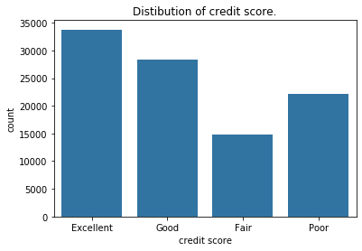

```python
# visualise the loan status distribution
base_color = sb.color_palette()[0]
sb.countplot(data=df_clean, x= 'credit_score', color=base_color)
plt.xlabel('credit score')
plt.title('Distibution of credit score.');
```

> **The distribution of credit scores shows that more people had excellent credit scores. Interestingly, those with poor credit scores are more than the fair ones.**

```python
df_clean.listing_category_numeric.unique()
```

```
array([ 0,  2, 16,  1,  7, 13,  6, 15, 20, 19, 18,  8,  4,  3, 11, 14,  5,
        9, 17, 10, 12], dtype=int64)
```

> **What was the general purpose highlighted for loans?**

```python
# map each purpose discription to numeric values indicated
purpose_list={0:'Not Available',1:'Debt Consolidation',2:'Home Improvement',3:'Business',4:'Personal Loan',5:'Student Use',6:'Auto',
 7:'Other',8:'Baby&Adoption',9:'Boat',10:'Cosmetic Procedure',11:'Engagement Ring',12:'Green Loans',
 13:'Household Expenses',14:'Large Purchases',15:'Medical/Dental',16:'Motorcycle',17:'RV',18:'Taxes',19:'Vacation',20:'Wedding Loans'}
```

```python
# create a new column for loan purpose with mapped values from dictionary keys
df_clean['loan_purpose']=df_clean.listing_category_numeric.map(purpose_list)
```

```python
# confirm changes
df_clean.sample(2)
```

|  | loan_key | term | loan_status | borrower_apr | borrower_rate | listing_category_numeric | borrower_state | occupation | employment_status | loan_original_amount | debt_to_income_ratio | investors | stated_monthly_income | monthly_loan_payment | income_verifiable | is_borrower_homeowner | credit_score_avg | credit_score | loan_purpose |
| --- | --- | --- | --- | --- | --- | --- | --- | --- | --- | --- | --- | --- | --- | --- | --- | --- | --- | --- | --- |
| 19059 | 313B3703608748335884B97 | 36 | Current | 0.15223 | 0.1239 | 1 | SC | Skilled Labor | Employed | 10000 | 0.33 | 1 | 3750.000000 | 334.01 | True | False | 689.5 | Good | Debt Consolidation |
| 53865 | A9DE3650258681712EFF484 | 36 | Current | 0.21372 | 0.1768 | 13 | NJ | Police Officer/Correction Officer | Employed | 11000 | 0.12 | 152 | 8333.333333 | 395.91 | True | False | 709.5 | Good | Household Expenses |

```python
#check new column values
df_clean['loan_purpose'].unique()
```

```
array(['Not Available', 'Home Improvement', 'Motorcycle',
       'Debt Consolidation', 'Other', 'Household Expenses', 'Auto',
       'Medical/Dental', 'Wedding Loans', 'Vacation', 'Taxes',
       'Baby&Adoption', 'Personal Loan', 'Business', 'Engagement Ring',
       'Large Purchases', 'Student Use', 'Boat', 'RV',
       'Cosmetic Procedure', 'Green Loans'], dtype=object)
```

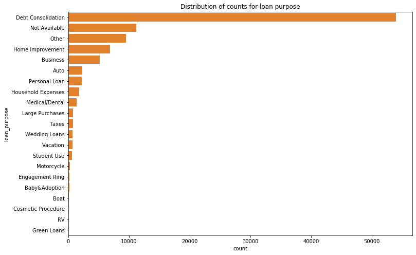

```python
# Plotting countplot.
base_color2 = sb.color_palette()[1]
plt.figure(figsize=(12,8))
sb.countplot(y='loan_purpose',data= df_clean, order= df_clean['loan_purpose'].value_counts().index, color=base_color2)
plt.title('Distribution of counts for loan purpose');
```

> **Most people highlighted debt consolidation as the major purpose for acquiring loans.**

> **Which state contributed more in loan acquisition?**

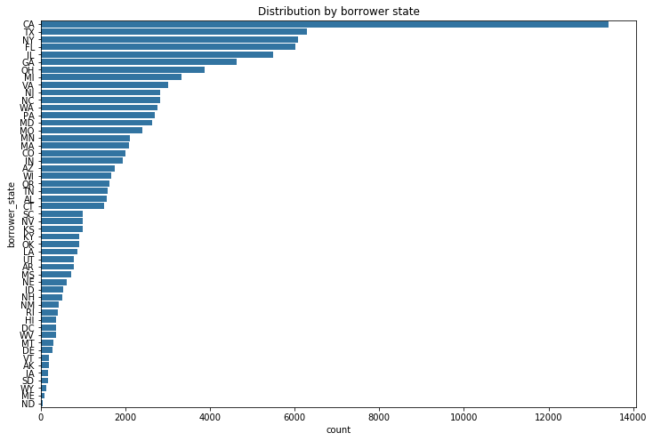

```python
# Plot countplot.
base_color2 = sb.color_palette()[0]
plt.figure(figsize=(12,8))
sb.countplot(y='borrower_state',data= df_clean, order= df_clean['borrower_state'].value_counts().index, color=base_color2)
plt.title('Distribution by borrower state');
```

> **The graph shows that the maximum number of borrowers were from california (CA).**

> **How did the employment status contribute in loan acquisition?**

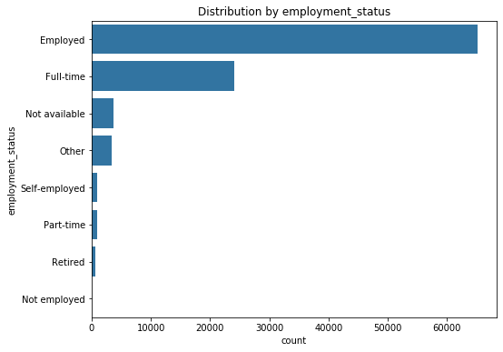

```python
# Plot countplot.
base_color2 = sb.color_palette()[0]
plt.figure(figsize=(8,6))
sb.countplot(y='employment_status',data= df_clean, order= df_clean['employment_status'].value_counts().index, color=base_color2)
plt.title('Distribution by employment_status');
```

> **From the graph its safe to say the majority of borrowers are employed and with fulltime jobs.**

> **How is the distribution of loan original amount?**

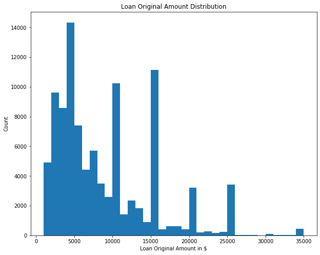

```python
# get the disrtibution of Loan Original Amount

bins = np.arange(df_clean['loan_original_amount'].min(), df_clean['loan_original_amount'].max()+1000, 1000)

plt.figure(figsize=[10, 8])
plt.hist(data = df_clean, x = 'loan_original_amount', bins = bins)
plt.title('Loan Original Amount Distribution')
plt.xlabel('Loan Original Amount in $')
plt.ylabel('Count')
```

> **Notice the graph is skewed to the right**

> **Re-plot on a log scale for improved clarity of visuals**

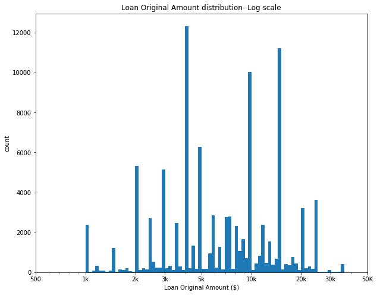

```python
# replot on log scale
bins = 10 ** np.arange(3, np.log10(df_clean['loan_original_amount'].max())+0.020, 0.020)

plt.figure(figsize=[10, 8])
plt.hist(data = df_clean, x = 'loan_original_amount', bins = bins)
plt.title('Loan Original Amount distribution- Log scale')
plt.xscale('log')
plt.xticks([500, 1e3, 2e3,3e3, 5e3, 1e4, 2e4, 3e4, 5e4], ['500', '1k', '2k', '3k', '5k', '10k', '20k', '30k', '50K'])
plt.xlabel('Loan Original Amount ($)')
plt.ylabel('count')
```

> **The most frequent loan amount is roughly 4k, with other peaks of between 9k to 15k amounts.**

> **What is the distribution of stated monthly income?**

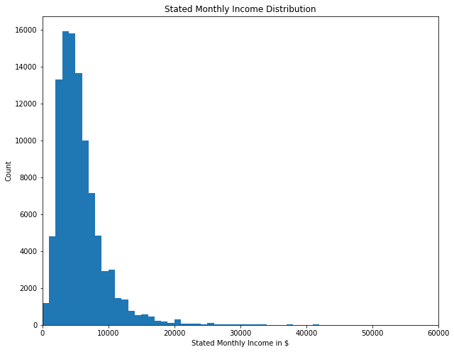

```python
#get the disrtibution of Stated Monthly Income
#limit to $60000 to exclude outliers

bins = np.arange(df_clean['stated_monthly_income'].min(), 51000, 1000)
plt.figure(figsize=[10, 8])
plt.hist(data = df_clean, x = 'stated_monthly_income', bins = bins)
plt.title('Stated Monthly Income Distribution')
plt.xlabel('Stated Monthly Income in $')
plt.ylabel('Count')
plt.xlim(0, 60000);
```

> Notice, the distribution is right skewed with a long tail.Most earners get between 3300 and 7000.

### Discuss the distribution(s) of your variable(s) of interest. Were there any unusual points? Did you need to perform any transformations?

> Utilized some transformation on loan original amount variable, and borrower rate including: changing x-ticks to view more exact point of interest, altering bins sizes to reduce noise in the graph and view data more precisely and utilising log xscale to make interpretations from the graph easy.

### Of the features you investigated, were there any unusual distributions? Did you perform any operations on the data to tidy, adjust, or change the form of the data? If so, why did you do this?

> In order to produce visually descriptive display, for the loan purpose, mapped numeric variables in the list category features to its descriptive text form.

> Added a feature by categorizing credit scores from interquatile cut-off values.

## Bivariate Exploration

> First create two categories non-numeric and numeric, to determine proper chart types in checking any associations between varibles.

```python
num_variables= ['term','borrower_apr','borrower_rate', 'loan_original_amount',
                'debt_to_income_ratio', 'stated_monthly_income', 'monthly_loan_payment','credit_score_avg']
```

```python
cat_variables=['loan_status','borrower_state','occupation','employment_status','is_borrower_homeowner',
              'credit_score','loan_purpose']
```

> **Which numerical features are closely related?**

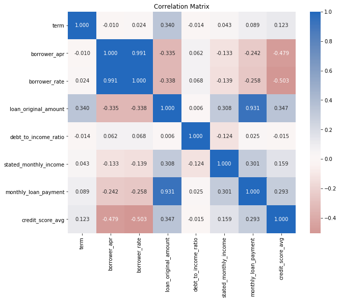

```python
# Create a correlation matrix for numeric variables
plt.figure(figsize = [10, 8])
sb.heatmap(df_clean[num_variables].corr(), annot = True, fmt = '.3f',
           cmap = 'vlag_r', center = 0)
plt.title('Correlation Matrix');
```

```python
# reset index
df_clean.reset_index(inplace=True)
```

```python
df_clean.drop('index',axis=1,inplace=True)
```

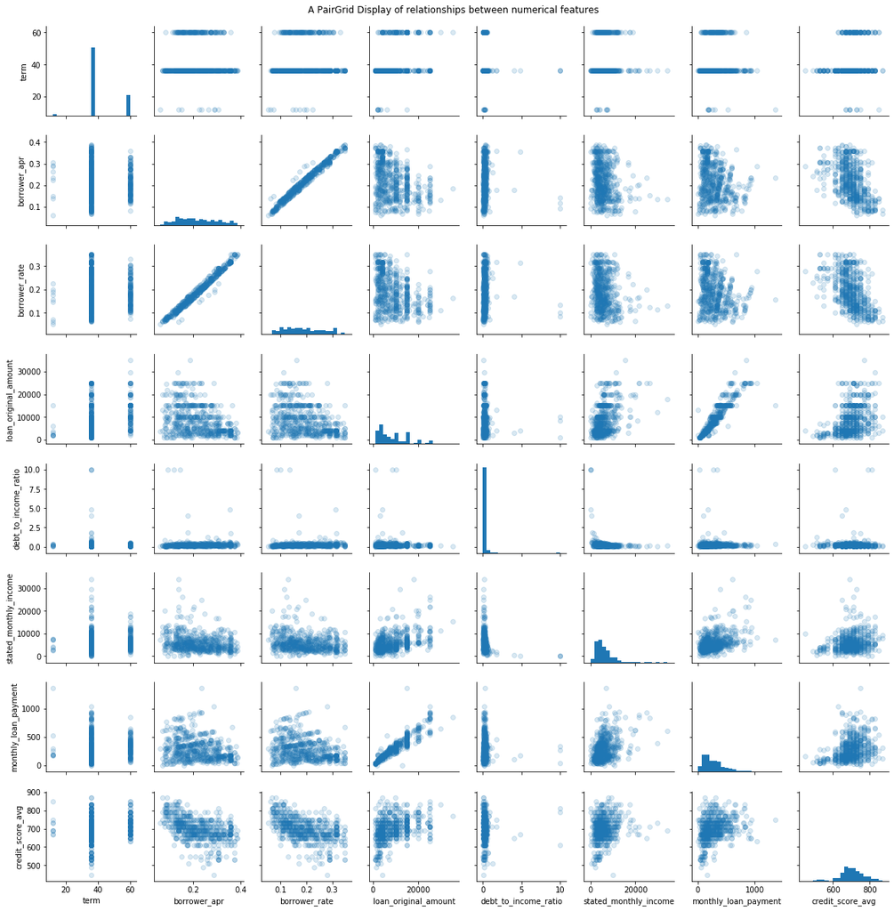

```python
# for a clearer assessment, extract a random sample of 600
# to complement hitmap, plot PairGrid to visualise relationships
samples = np.random.choice(df_clean.shape[0], 600, replace = False)
chunk = df_clean.loc[samples,:]
x = sb.PairGrid(data = chunk, vars = num_variables,height=2)
x = x.map_diag(plt.hist, bins = 20)
x.map_offdiag(plt.scatter,alpha=1/6)
x.fig.suptitle('A PairGrid Display of relationships between numerical features',y=1.02);
```

> From the hitmap and Pairgrid visuals, of significance include: A positive correlation between Borrower APR and Borrower Rate, financially, a very logical association. A similar positive correlation outcome is observed with original loan amount and monthly loan payment.

> Albeit not strong there is a negative correlation between both borrower-APR and borrower rate to credit score average.

> **Is there any association between borrower-APR and stated monthly income?**

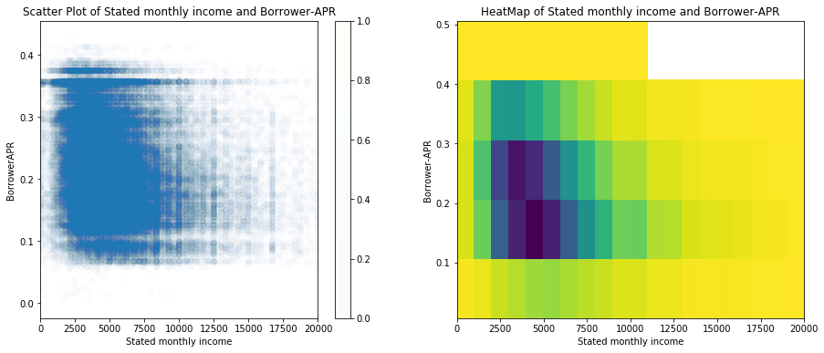

```python
#plot borrower APR vs stated monthly income
# note; exclude outliers -only income below $200000 for better relationship clarity
plt.figure(figsize = [15, 6])
plt.subplot(1, 2, 1)
plt.scatter(data = df_clean, x = 'stated_monthly_income', y = 'borrower_apr',  alpha =  0.01)
plt.title('Scatter Plot of Stated monthly income and Borrower-APR')
plt.xlabel('Stated monthly income')
plt.ylabel('BorrowerAPR')
plt.xlim(0, 20000)
plt.colorbar();

plt.subplot(1, 2, 2)
bins_x = np.arange(df_clean['stated_monthly_income'].min(), 210000, 1000)
bins_y = np.arange(df_clean['borrower_apr'].min(), df_clean['borrower_apr'].max()+0.1, 0.1)
plt.hist2d(data = df_clean, x = 'stated_monthly_income', y = 'borrower_apr',bins = [bins_x, bins_y],  cmap = 'viridis_r', cmin = 0.5)
plt.title('HeatMap of Stated monthly income and Borrower-APR')
plt.xlabel('Stated monthly income')
plt.xlim(0, 20000)
plt.ylabel('Borrower-APR');
```

> Looking at the hitmap, a lot of borrower-APRs are around 0.1 to 0.3 and are concentrated at monthly income levels of between 2500 and 6000, which may not be anything but corresponding to the bracket of most earners in the population.

> **How is the association of borrower APR to loan status?**

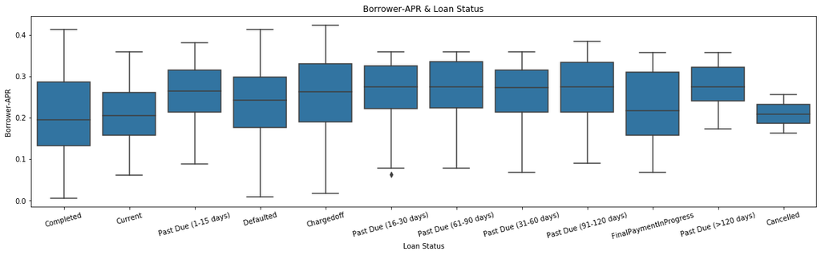

```python
# plot Borrower APR vs Status of Loan
plt.figure(figsize = [20, 5])
sb.boxplot(data=df_clean,y='borrower_apr',x='loan_status',color=base_color);
plt.title('Borrower-APR & Loan Status')
plt.ylabel('Borrower-APR')
plt.xlabel('Loan Status')
plt.xticks(rotation=15);
```

> Completed loans had a median borower- APR of approximately 0.2, which is lower than other categories, particularly charged-off and past-due loans.

> **Does the credit score influence borrower APR?**

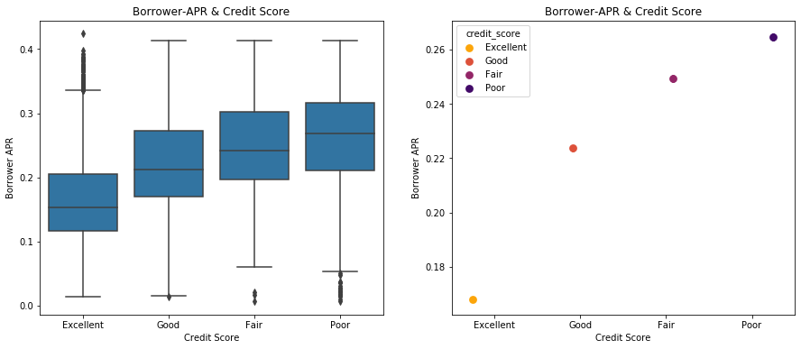

```python
# plot Borrower APR vs Credit Score
plt.figure(figsize = [15, 6])
plt.subplot(1, 2, 1)
sb.boxplot(data=df_clean,y='borrower_apr',x='credit_score',color=base_color);
plt.title('Borrower-APR & Credit Score')
plt.ylabel('Borrower APR')
plt.xlabel('Credit Score');

plt.subplot(1, 2, 2)
sb.pointplot(data=df_clean,y='borrower_apr',x='credit_score',color=base_color,
            hue = 'credit_score', linestyles = "",
                  dodge = 0.5, palette = 'inferno_r');
plt.title('Borrower-APR & Credit Score')
plt.ylabel('Borrower APR')
plt.xlabel('Credit Score');
```

> The trend shows that the borrower-APR is lower with excellent credit scores,with the pattern consistently inversely related across.

> **Does employment status have any influence to borrower's APR?**

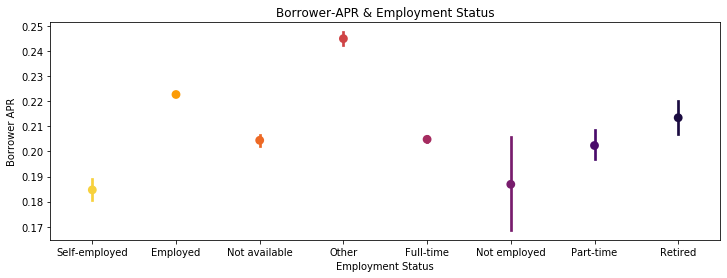

```python
#plot Borrower APR and Employment Status
plt.figure(figsize = [12, 4])

sb.pointplot(data=df_clean,y='borrower_apr',x='employment_status',color=base_color,
             linestyles="", palette = 'inferno_r');
plt.title('Borrower-APR & Employment Status')
plt.ylabel('Borrower APR')
plt.xlabel('Employment Status');
```

> Interestingly the employed category had a high borrower-APR than self-employed and not-employed groups.

> The categorised *other* had much higher borrower-APR compared to the rest.

> **Is there any association between borrower APR and loan purpose?**

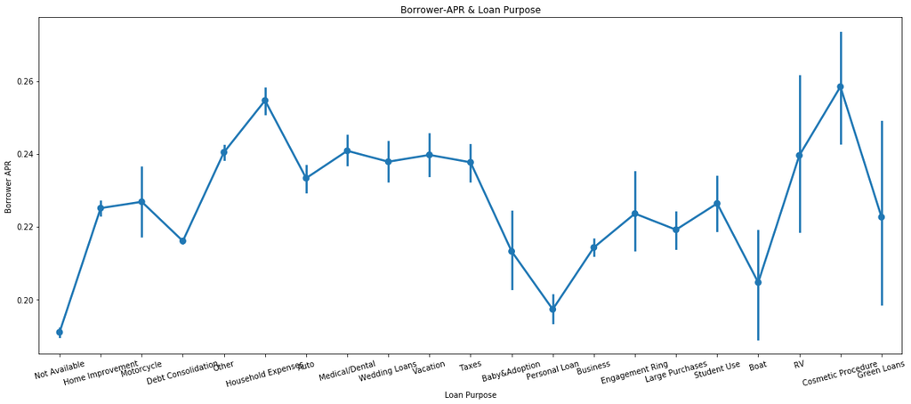

```python
#plot Borrower APR and Loan Purpose
plt.figure(figsize = [20, 8])
sb.pointplot(data=df_clean,y='borrower_apr',x='loan_purpose',color=base_color);
plt.title('Borrower-APR & Loan Purpose')
plt.ylabel('Borrower APR')
plt.xlabel('Loan Purpose')
plt.xticks(rotation=15);
```

> Besides the *not available group*, those loans indicated as personal seem to attract a lower borrower APR and with cosmetic procedure the heighest.

> **Does owning a home or credit score affect loan status?**

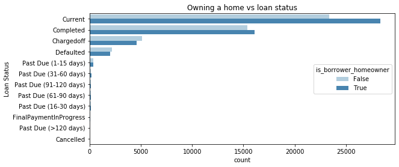

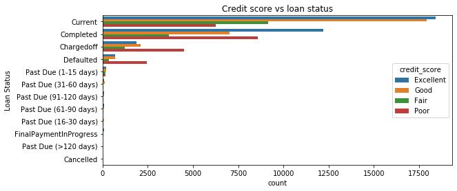

```python
#plot loan status vs is_borrower_homeowner
plt.figure(figsize = [20, 4])
plt.subplot(1, 2, 1)
sb.countplot(data = df_clean, y = 'loan_status', hue = 'is_borrower_homeowner', palette = 'Blues',
             order= df_clean['loan_status'].value_counts().index)
plt.title('Owning a home vs loan status')
plt.xlabel('count')
plt.ylabel('Loan Status');

plt.figure(figsize = [20, 4])
plt.subplot(1, 2, 2)
sb.countplot(data = df_clean, y = 'loan_status', hue = 'credit_score',
             order= df_clean['loan_status'].value_counts().index)
plt.title('Credit score vs loan status')
plt.xlabel('count')
plt.ylabel('Loan Status');
```

> Owning a home seems had a bearing on loan status, with the majority having current and completed loans, and this trend is slightly the opposite with those defaulted and charged-off.

> Most borrowers with excellent credit scores had current or completed loans, were as expected borrowers with defaulted and charged-off had poor credit scores more often.

> **Is there any relationship between employment and loan status?**

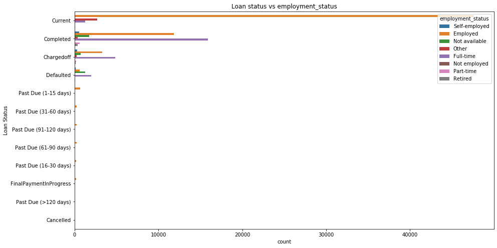

```python
#plot countplot for loan status vs employment status.
plt.figure(figsize = [15, 8])
sb.countplot(data = df_clean, y = 'loan_status', hue = 'employment_status',
             order= df_clean['loan_status'].value_counts().index)
plt.title('Loan status vs employment_status')
plt.xlabel('count')
plt.ylabel('Loan Status');
```

### Talk about some of the relationships you observed in this part of the investigation. How did the feature(s) of interest vary with other features in the dataset?

#### Summary of findings:

> A positive correlation between Borrower APR and Borrower Rate, similarly a positive correlation outcome is observed with original loan amount and monthly loan payment.

> Albeit not strong there is a negative correlation between both borrower-APR and borrower rate to credit score average.

> Borrower-APRs of around 0.1 to 0.3 are common and are concentrated at monthly income levels of between 2500 and 6000.

> Completed loans had a median borower- APR of approximately 0.2, which is lower than other categories, particularly charged-off and past-due loans.

> borrower-APR was lower with excellent credit scores,with the pattern consistently inversely related across other credit score groups.

> The employed category had a high borrower-APR than self-employed and not-employed groups, the categorised other had much higher borrower-APR compared to the rest.

> Owning a home had a bearing on loan status, with the majority having current and completed loans, and this trend is slightly the opposite with those defaulted and charged-off.

> Most borrowers with excellent credit scores had current or completed loans, were as expected borrowers with defaulted and charged-off had poor credit scores more often.

## Multivariate Exploration

```python
def hist2dgrid(x, y, **kwargs):
    palette = kwargs.pop('color')
    plt.hist2d(x, y, cmap = palette, cmin = 0.5)
```

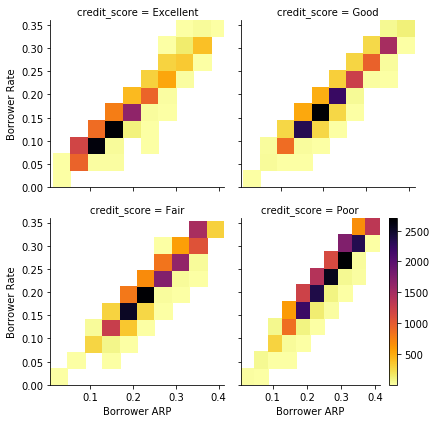

```python
# create faceted heat maps on levels of the credit score variable
g = sb.FacetGrid(data = df_clean, col = 'credit_score', col_wrap = 2, height = 3)
g.map(hist2dgrid, 'borrower_apr', 'borrower_rate', color = 'inferno_r')
g.set_xlabels('Borrower ARP')
g.set_ylabels('Borrower Rate')
plt.colorbar()
```

> The trend looks like as the borrower rate and APR are lower, the higher the credit scores. Borrow rate and APR are roughly below 0.2 and 0.3 respectevely for excellent and good credit scores. And these are concentrated higher up in fair and poor credit score groups.

```python
df_clean.head()
```

|  | loan_key | term | loan_status | borrower_apr | borrower_rate | listing_category_numeric | borrower_state | occupation | employment_status | loan_original_amount | debt_to_income_ratio | investors | stated_monthly_income | monthly_loan_payment | income_verifiable | is_borrower_homeowner | credit_score_avg | credit_score | loan_purpose |
| --- | --- | --- | --- | --- | --- | --- | --- | --- | --- | --- | --- | --- | --- | --- | --- | --- | --- | --- | --- |
| 0 | E33A3400205839220442E84 | 36 | Completed | 0.16516 | 0.1580 | 0 | CO | Other | Self-employed | 9425 | 0.17 | 258 | 3083.333333 | 330.43 | True | True | 649.5 | Poor | Not Available |
| 1 | 9E3B37071505919926B1D82 | 36 | Current | 0.12016 | 0.0920 | 2 | CO | Professional | Employed | 10000 | 0.18 | 1 | 6125.000000 | 318.93 | True | False | 689.5 | Good | Home Improvement |
| 2 | 6954337960046817851BCB2 | 36 | Completed | 0.28269 | 0.2750 | 0 | GA | Other | Not available | 3001 | 0.06 | 41 | 2083.333333 | 123.32 | True | False | 489.5 | Poor | Not Available |
| 3 | A0393664465886295619C51 | 36 | Current | 0.12528 | 0.0974 | 16 | GA | Skilled Labor | Employed | 10000 | 0.15 | 158 | 2875.000000 | 321.45 | True | True | 809.5 | Excellent | Motorcycle |
| 4 | A180369302188889200689E | 36 | Current | 0.24614 | 0.2085 | 2 | MN | Executive | Employed | 15000 | 0.26 | 20 | 9583.333333 | 563.97 | True | True | 689.5 | Good | Home Improvement |

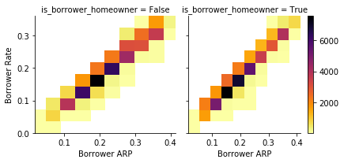

```python
# plot faceted heat maps on levels of the is_borrower_homeowner feature
col1='is_borrower_homeowner'
g = sb.FacetGrid(data = df_clean, col = col1, col_wrap = 2, height = 3)
g.map(hist2dgrid, 'borrower_apr', 'borrower_rate',color = 'inferno_r')
g.add_legend()
g.set_xlabels('Borrower ARP')
g.set_ylabels('Borrower Rate')
plt.colorbar()
```

The plots shows a slight decrease in borrower rate and APR points when borrowers are homeowner than not.

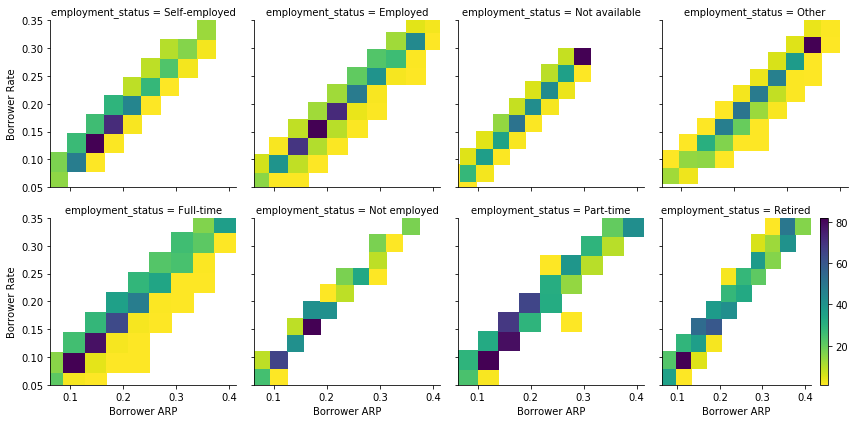

```python
# plot faceted heat maps on levels of the employment_status feature
g = sb.FacetGrid(data = df_clean, col = 'employment_status', col_wrap = 4, height = 3)
g.map(hist2dgrid, 'borrower_apr', 'borrower_rate', color = 'viridis_r')
g.set_xlabels('Borrower ARP')
g.set_ylabels('Borrower Rate')
plt.colorbar()
```

> From the plots, borrower rate and APR points are concentrated at higher ends for employment status classed as other and not available.Somehow, can confirm the effect on employment status to borrower rate and APR.

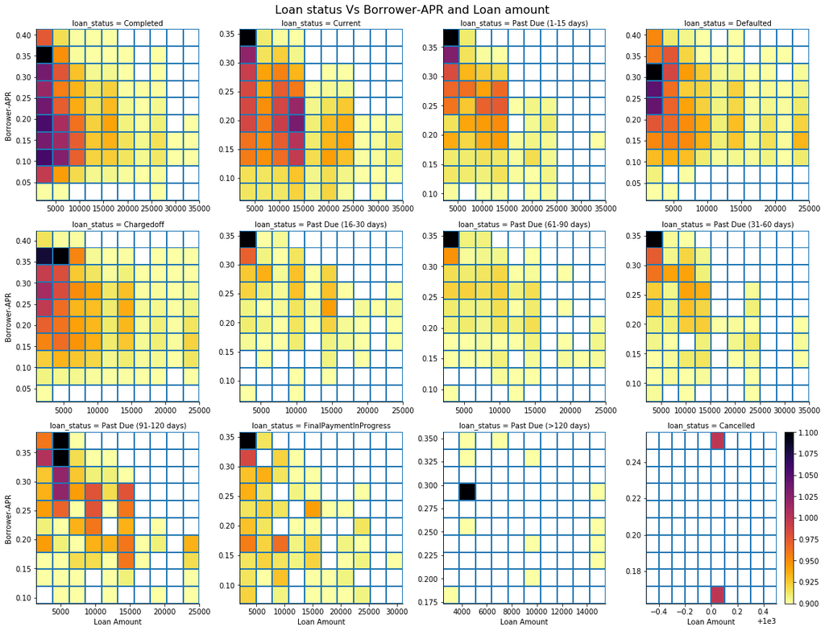

```python
g = sb.FacetGrid(data = df_clean, col = 'loan_status', col_wrap = 4, height = 4,
                 sharex=False,sharey=False)
g.map(plt.hist2d, 'loan_original_amount', 'borrower_apr',cmap = 'inferno_r',cmin=0.5)
g.set_xlabels('Loan Amount')
g.set_ylabels('Borrower-APR')
g.fig.suptitle('Loan status Vs Borrower-APR and Loan amount',y=1.01, fontsize=16)
plt.colorbar()
```

> There is no clear picture of any association between loan amounts, borrower ARP and loan status. But however, the majority of points are concentrated at the ARP of 0.35 and amounts close to or less than 5000. No clear systematic interaction of the 3 features observed.

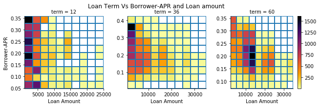

```python
g = sb.FacetGrid(data = df_clean, col = 'term', col_wrap = 3, height = 3,
                 sharex=False,sharey=False)
g.map(plt.hist2d, 'loan_original_amount', 'borrower_apr',cmap = 'inferno_r',cmin=0.5)
g.set_xlabels('Loan Amount')
g.set_ylabels('Borrower-APR')
g.fig.suptitle('Loan Term Vs Borrower-APR and Loan amount', y=1.01)
plt.colorbar()
```

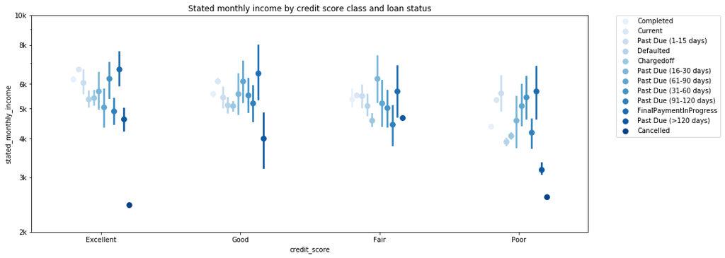

```python
# Plot pointplot stated monthly income vs credit score and loan status.
fig = plt.figure(figsize = [15,6])
ax = sb.pointplot(data = df_clean, x = 'credit_score', y = 'stated_monthly_income',
                   hue = 'loan_status',palette = 'Blues', linestyles = '', dodge = 0.4)
plt.yscale('log')# log transfom on y-axis
plt.yticks([2e3, 3e3, 4e3,5e3,6e3,8e3,10e3], ['2k', '3k','4k','5k','6k','8k','10k'])
ax.set_yticklabels([],minor = True)
plt.legend(bbox_to_anchor=(1.05, 1), loc='upper left', borderaxespad=0)
plt.title('Stated monthly income by credit score class and loan status')
```

> The point plot review a slight shift from excellent to poor credit scores of decreasing stated monthly incomes.However, there is no clear sytematic interaction of monthly income and loan status that is evident from this graph.

### Talk about some of the relationships you observed in this part of the investigation. Were there features that strengthened each other in terms of looking at your feature(s) of interest?

> The strength of the correlation between borrower rate and borrower ARP seems not to be affected by any other features assessed in the data set.

### Were there any interesting or surprising interactions between features?

> During the bivaiate exploratory analysis, interestingly the employed category had a high borrower-APR than self-employed and not-employed groups. It turns out that on multivariate analysis the not employed status had in fact fewer data points to validate association with lower borrower APR.

> From the plots, it doesn't seem like there's a systematic interaction effect between some of the observed categorical features. However, it can be argued that some of the features aren't fully independent, and also given that a lot of features were not analysed, further exploration maybe warranted.